# guide

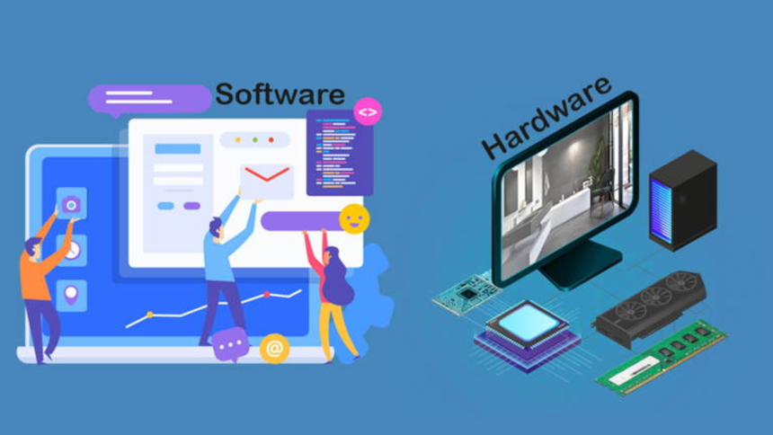

Hardware - Software - Users. Fuente: digitalek.com

### 1. ¿Qué es un sistema informático?

Un sistema informático es un conjunto de elementos que trabajan juntos para procesar información.

Está formado por:

- **Hardware**: partes físicas (lo que se puede tocar)
- **Software**: programas (lo que da instrucciones)
- **Usuario**: quien utiliza el sistema

🔹 Idea clave: *ninguno funciona solo, siempre trabajan juntos.*

#### Actividad 1

Conexión con Inglés

Aprende el significado y pronunciación de “hard” y “soft”. Luego copia la siguiente frase en la carpeta pero completando las palabras que faltan.

*Hardware come from _____ (physical parts) and software _____ from “soft” (intangible instructions). _____ work with users to operate a computer system.*

### 2. Reconociendo un sistema informático

Observa un dispositivo digital o una computadora que utilices habitualmente (puede ser una PC, notebook, tablet o celular).

Respondé:

- ¿Qué partes del dispositivo podés identificar como hardware?
- ¿Qué programas o aplicaciones utilizas en ese dispositivo (software)?
- ¿Qué periféricos de entrada y salida intervienen cuando lo usas (teclado, mouse, pantalla, parlantes, etc.)?
- ¿Cómo circula la información cuando realizás una acción simple, como escribir un mensaje o abrir un programa?

**Ejemplo:**

Enviar un mensaje por WhatsApp

- Hardware: celular, pantalla, batería
- Software: aplicación WhatsApp, sistema operativo
- Usuario: la persona que escribe y envía

#### Actividad 2

Identificá los componentes:

1. Imprimir un archivo
2. Ver un video en YouTube
3. Escribir un texto

**Respuesta (autocorrección):**

**Ver respuestas**

1. Hardware: impresora, PC  
   Software: programa de impresión  
   Usuario: quien imprime
2. Hardware: celular/PC  
   Software: navegador/app  
   Usuario: quien mira
3. Hardware: teclado, monitor  
   Software: procesador de texto  
   Usuario: quien escribe

### 3. Hardware

El hardware se puede clasificar según su función:

- **Entrada**: teclado, mouse
- **Salida**: monitor, impresora
- **Procesamiento**: CPU
- **Almacenamiento**: disco, pendrive

#### Actividad 3

Haz un esquema de los componentes principales del hardware usando la aplicación Paint. Para esto:

1. Copia la imagen de abajo (por ejemplo con la tecla “Imprimir Pantalla”) y pégala en Paint.
2. Arréglala de modo que quede limpia y de tamaño adecuado.
3. Agrega los nombres de cada componente numerado tanto en español como en inglés. Por ejemplo: **(1)** Pantalla / Screen.

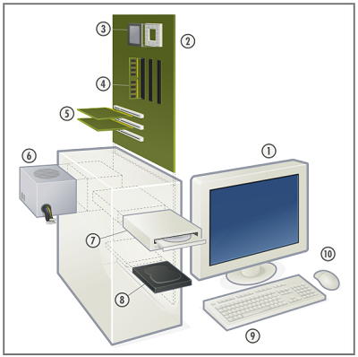

Fuente: internet

**Importante** debes mostrar la pantalla con la tarea hecha en tiempo de clase, es una de las condiciones para aprobar esta unidad.

### 4. Software

El software indica qué hacer al hardware.

Tipos:

- **Sistema operativo**: controla el equipo (Windows, Android)
- **Aplicaciones**: programas que usamos (Word, navegador)

El software funciona como por capas, por ejemplo la capa que comanda más directamete el usuario es la capa de aplicaciones como se muestra abajo.

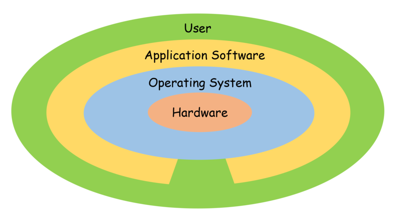

Fuente: internet

#### Actividad 4

**a)** Haz un dibujo en la carpeta como el anterior pero poniendo los nombres en español.

**b)** Investiga y escribe brevemente en tres reglones las formas de interactuar con el sistema operativo que tiene el usuario. En tu explicación tienen que aparecer las frases: “interfaz gráfica” y “intérprete de comando”.